# Practical 2: Data Visualisation

Nina van Gerwen (1860852)

2022-09-20

### Question 1

Aesthetics: aes(x = Hits, y = HmRun) Geoms: 1) geom_point() for the scatterplot 2) geom_density_2d() for the weird circles Scales: xlab = “Hits, ylab =”Home runs”, labs(title = “…”) Themes: theme_minimal()

As for statistical transformations, I believe geom_density_2d() does this as it performs a 2D kernel density estimation.

### Question 2

```r
set.seed(1234)
student_grade  <- rnorm(32, 7)
student_number <- round(runif(32) * 2e6 + 5e6)
programme      <- sample(c("Science", "Social Science"), 32, replace = TRUE)

gg_students <- data.frame(student_number, student_grade, programme)
```

### Question 3

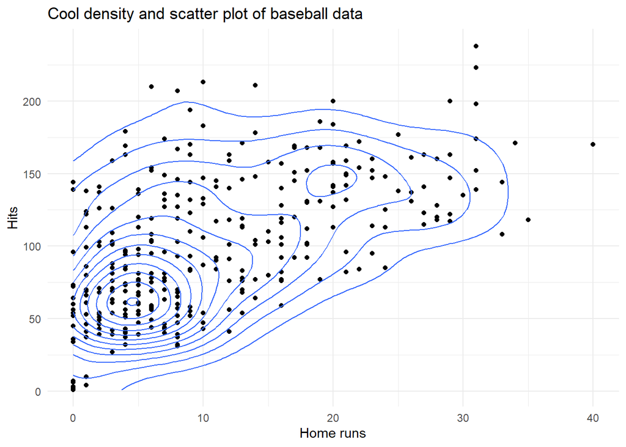

```r
rev_homeruns_plot <- ggplot(data = Hitters, aes(x = HmRun, y = Hits)) +
  geom_point() +
  labs(x = "Home runs", y = "Hits") +
  geom_density_2d() +
  labs(title = "Cool density and scatter plot of baseball data") +
  theme_minimal()

rev_homeruns_plot
```

### Question 4

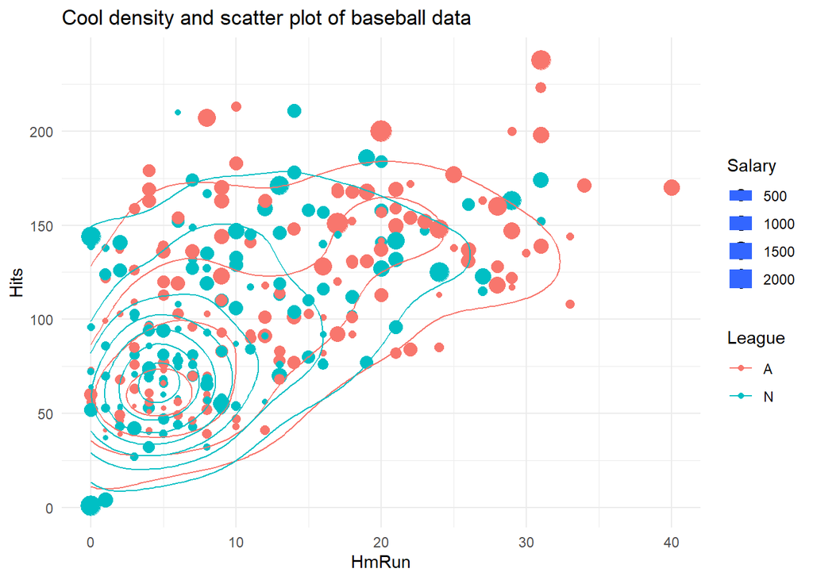

```r
upgraded_homeruns_plot <- rev_homeruns_plot + aes(x = HmRun, y = Hits,
                                                  col = League,
                                                  size = Salary)

upgraded_homeruns_plot
```

### Question 5

There are indeed many geoms.

### Question 6

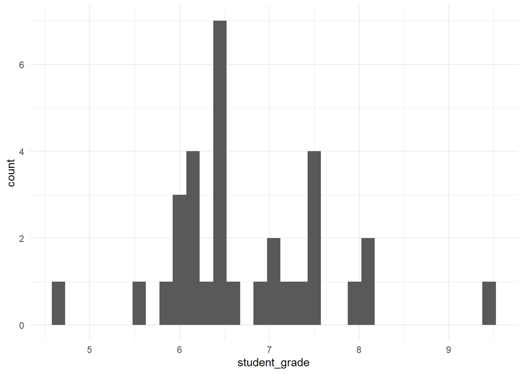

```r
student_hist <- ggplot(data = gg_students, aes(x = student_grade)) +
  geom_histogram(binwidth = 0.15) +
  theme_minimal()

student_hist
```

### Question 7

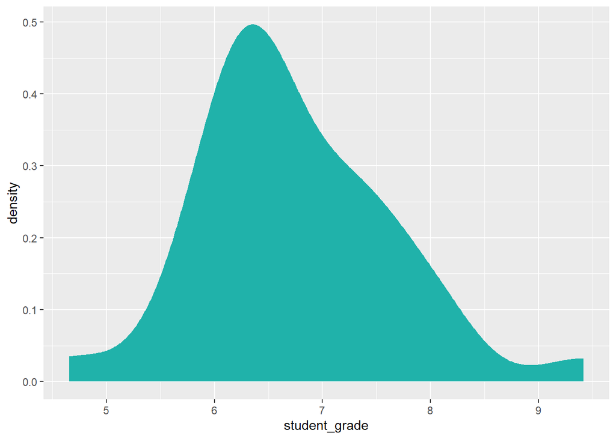

```r
student_dens <- ggplot(data = gg_students, aes(x = student_grade)) +
  geom_density(fill = "light seagreen", col = NA)

student_dens
```

A very pretty colour indeed.

### Question 8

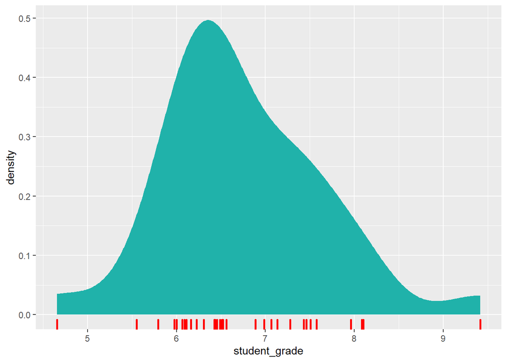

```r
upgr_student_dens <- student_dens +
  geom_rug(col = "red", size = 1)

upgr_student_dens
```

### Question 9

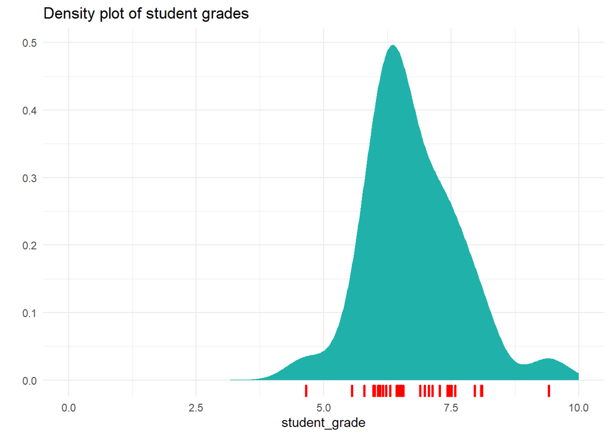

```r
upgr_student_dens +
  xlim(0, 10) +
  labs(y = "", title = "Density plot of student grades") +
  theme_minimal()
```

I had already removed the border in the first graph.

### Question 10

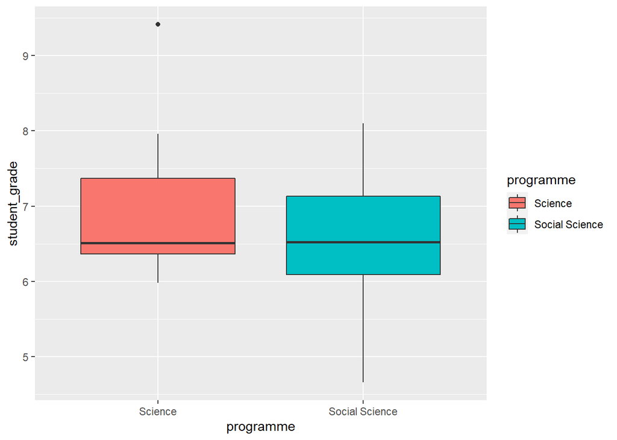

```r
ggplot(data = gg_students, aes(y = student_grade, x = programme,
                                                  fill = programme)) +
  geom_boxplot()
```

### Question 12

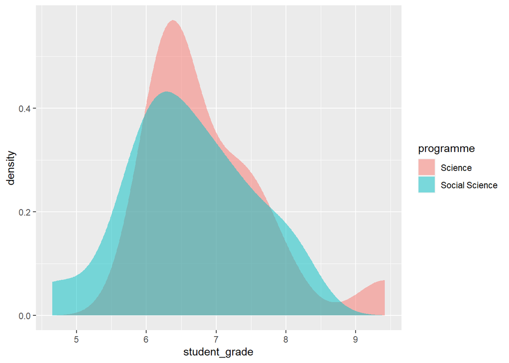

```r
ggplot(data = gg_students, aes(x = student_grade, fill = programme)) +
  geom_density(col = NA, alpha = .5)
```